# Course Notes | Text Mining with R | DataCamp

Peter

2019-05-28

# Visualizing Text

While counts are nice, visualizations are better. In this chapter, you will learn how to apply what you know and love from ggplot2 to tidy text data.

## Plotting word counts

**Starting with tidy text**

```r
tidy_review <- review_data %>%
  mutate(id = row_number()) %>%
  unnest_tokens(word, Review) %>%
  anti_join(stop_words)
## Joining, by = "word"

tidy_review %>%
  head(3)
## # A tibble: 3 x 6
##   Date     Product                    Stars Title               id word
##   <chr>    <chr>                      <dbl> <chr>            <int> <chr>
## 1 1/12/15  iRobot Roomba 650 for Pets     4 Four Stars           2 walk
## 2 1/12/15  iRobot Roomba 650 for Pets     4 Four Stars           2 rest
## 3 12/26/13 iRobot Roomba 650 for Pets     5 Awesome love it.     3 roomba
```

**Visualizing counts with geom_bar()**

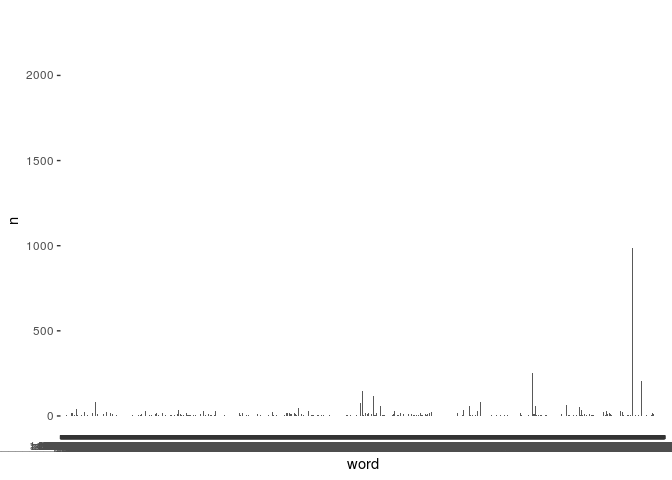

```r
word_counts <- tidy_review %>%
  count(word) %>%
  arrange(desc(n))

ggplot(word_counts, aes(word, n)) +
  geom_col()
```

**filter() before visualizing**

```r
word_counts2 <- tidy_review %>%
  count(word) %>%
  filter(n > 300) %>%
  arrange(desc(n))

word_counts2 %>% head(2)
## # A tibble: 2 x 2
##   word       n
##   <chr>  <int>
## 1 roomba  2286
## 2 clean   1204
```

**Using coord_filp()**

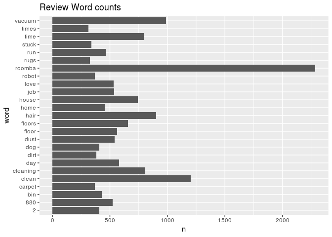

```r
ggplot(word_counts2, aes(word, n)) +
  geom_col() +
  coord_flip() +
  ggtitle("Review Word counts")
```

## Visualizing complaints

### Exercise

We ended the last chapter with complaint word counts. Now let’s visualize those word counts with a bar plot.

The `tidyverse` and `tidytext` packages have been loaded. `twitter_data` has been tokenized and the standard stop words have been removed.

### Instructions

Only keep the words with counts greater than 100. Create a bar plot using `word_counts` with `word` mapped to the x-axis. Flip the plot coordinates.

### script.R

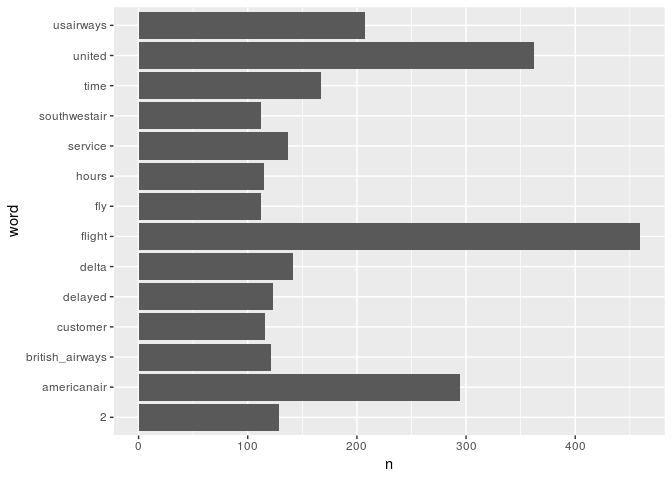

```r
word_counts <- tidy_twitter %>%
  filter(complaint_label == "Complaint") %>%
  count(word) %>%
  # Keep words with count greater than 100
  filter(n > 100)

# Create a bar plot using word_counts with x = word
ggplot(word_counts, aes(word, n)) +
  geom_col() +
  # Flip the plot coordinates
  coord_flip()
```

## Visualizing non-complaints

### Exercise

Now let’s visualize the word counts associated with non-complaints.

### Instructions

Only keep the non-complaints. Create a bar plot using the new `word_counts`. Title the plot “Non-Complaint Word Counts”.

### script.R

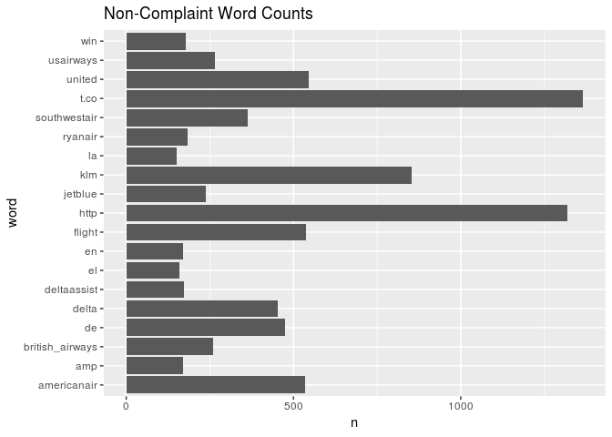

```r
word_counts <- tidy_twitter %>%
  # Only keep the non-complaints
  filter(complaint_label == "Non-Complaint") %>%
  count(word) %>%
  filter(n > 150)

# Create a bar plot using the new word_counts
ggplot(word_counts, aes(word, n)) +
  geom_col() +
  coord_flip() +
  # Title the plot "Non-Complaint Word Counts"
  ggtitle("Non-Complaint Word Counts")
```

## Improving word count plots

**Custom stop words**

```r
stop_words %>% head(3)
## # A tibble: 3 x 2
##   word  lexicon
##   <chr> <chr>
## 1 a     SMART
## 2 a's   SMART
## 3 able  SMART
```

**Using tribble()**

```r
tribble(
  ~word,    ~lexicon,
  "roomba", "CUSTOM",
  "2",      "CUSTOM"
)
## # A tibble: 2 x 2
##   word   lexicon
##   <chr>  <chr>
## 1 roomba CUSTOM
## 2 2      CUSTOM
```

**Using bind_rows()**

```r
custom_stop_words <- tribble(
  ~word,    ~lexicon,
  "roomba", "CUSTOM",
  "2",      "CUSTOM"
)

stop_words2 <- stop_words %>%
  bind_rows(custom_stop_words)
```

**Removing stop words again**

```r
tidy_review <- review_data %>%
  mutate(id = row_number()) %>%
  select(id, Date, Product, Stars, Review) %>%
  unnest_tokens(word, Review) %>%
  anti_join(stop_words2)
## Joining, by = "word"

tidy_review %>%
  filter(word == "roomba")
## # A tibble: 0 x 5
## # … with 5 variables: id <int>, Date <chr>, Product <chr>, Stars <dbl>,
## #   word <chr>
```

**Using fct_reorder()**

```r
word_counts <- tidy_review %>%
  count(word) %>%
  filter(n > 300) %>%
  mutate(word2 = fct_reorder(word, n))

word_counts %>% head(3)
## # A tibble: 3 x 3
##   word       n word2
##   <chr>  <int> <fct>
## 1 880      525 880
## 2 bin      428 bin
## 3 carpet   368 carpet
```

**Arranging the bar plot**

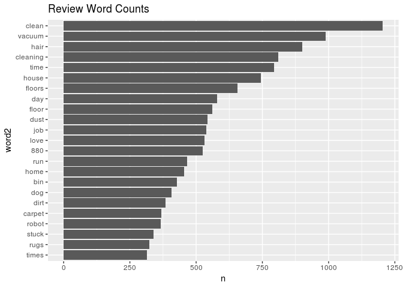

```r
ggplot(word_counts, aes(word2, n)) +
  geom_col() +
  coord_flip() +
  ggtitle("Review Word Counts")
```

## Adding custom stop words

### Exercise

We’ve seen a number of words in `twitter_data` that aren’t informative and should be removed from your final list of words. In this exercise, you will add a few words to your `custom_stop_words` data frame .

### Instructions

- The column names for the new data frame of custom stop words should match `stop_words`.
- Add `http`, `win`, and `t.co` as custom stop words.
- Row bind the custom stop words to `stop_words`.

### script.R

```r
custom_stop_words <- tribble(
  # Column names should match stop_words
  ~word, ~lexicon,
  # Add http, win, and t.co as custom stop words
  "http", "CUSTOM",
  "win", "CUSTOM",
  "t.co", "CUSTOM"
)

# Bind the custom stop words to stop_words
stop_words2 <- stop_words %>%
  rbind(custom_stop_words)
```

## Visualizing word counts using factors

### Instructions

- Only keep the terms that occur more than 100 times in the `non_complaints`.
- Reorder the `word` column as a factor ordered by word counts.
- Create a bar plot using the new word column with type factor.

### script.R

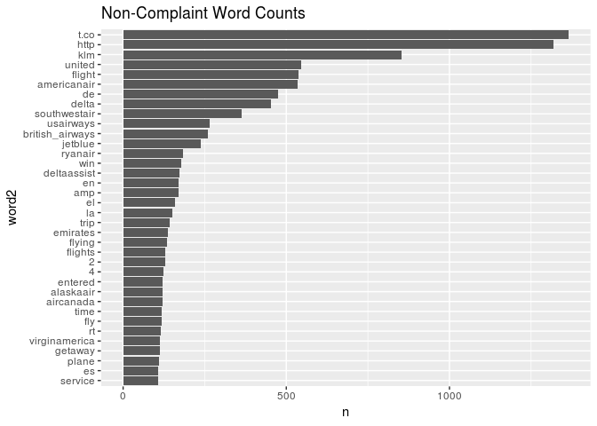

```r
word_counts <- tidy_twitter %>%
  filter(complaint_label == "Non-Complaint") %>%
  count(word) %>%
  # Keep terms that occur more than 100 times
  filter(n > 100) %>%
  # Reorder word as an ordered factor by word counts
  mutate(word2 = fct_reorder(word, n))

# Plot the new word column with type factor
ggplot(word_counts, aes(word2, n)) +
  geom_col() +
  coord_flip() +
  ggtitle("Non-Complaint Word Counts")
```

## Faceting word count plots

**Counting by Product**

```r
tidy_review %>%
  count(word, Product) %>%
  arrange(desc(n))
## # A tibble: 12,719 x 3
##    word     Product                                      n
##    <chr>    <chr>                                    <int>
##  1 clean    iRobot Roomba 880 for Pets and Allergies   815
##  2 vacuum   iRobot Roomba 880 for Pets and Allergies   678
##  3 hair     iRobot Roomba 880 for Pets and Allergies   595
##  4 cleaning iRobot Roomba 880 for Pets and Allergies   560
##  5 880      iRobot Roomba 880 for Pets and Allergies   518
##  6 house    iRobot Roomba 880 for Pets and Allergies   494
##  7 time     iRobot Roomba 880 for Pets and Allergies   494
##  8 floors   iRobot Roomba 880 for Pets and Allergies   405
##  9 love     iRobot Roomba 880 for Pets and Allergies   403
## 10 dust     iRobot Roomba 880 for Pets and Allergies   399
## # … with 12,709 more rows
```

**Using top_n()**

```r
tidy_review %>%
  count(word, Product) %>%
  group_by(Product) %>%
  top_n(10, n)
## # A tibble: 20 x 3
## # Groups:   Product [2]
##    word     Product                                      n
##    <chr>    <chr>                                    <int>
##  1 880      iRobot Roomba 880 for Pets and Allergies   518
##  2 clean    iRobot Roomba 650 for Pets                 389
##  3 clean    iRobot Roomba 880 for Pets and Allergies   815
##  4 cleaning iRobot Roomba 650 for Pets                 249
##  5 cleaning iRobot Roomba 880 for Pets and Allergies   560
##  6 day      iRobot Roomba 650 for Pets                 209
##  7 dust     iRobot Roomba 880 for Pets and Allergies   399
##  8 floor    iRobot Roomba 650 for Pets                 207
##  9 floors   iRobot Roomba 650 for Pets                 252
## 10 floors   iRobot Roomba 880 for Pets and Allergies   405
## 11 hair     iRobot Roomba 650 for Pets                 305
## 12 hair     iRobot Roomba 880 for Pets and Allergies   595
## 13 house    iRobot Roomba 650 for Pets                 251
## 14 house    iRobot Roomba 880 for Pets and Allergies   494
## 15 love     iRobot Roomba 880 for Pets and Allergies   403
## 16 run      iRobot Roomba 650 for Pets                 180
## 17 time     iRobot Roomba 650 for Pets                 301
## 18 time     iRobot Roomba 880 for Pets and Allergies   494
## 19 vacuum   iRobot Roomba 650 for Pets                 311
## 20 vacuum   iRobot Roomba 880 for Pets and Allergies   678
```

**Using ungroup()**

```r
tidy_review %>%
  count(word, Product) %>%
  group_by(Product) %>%
  top_n(10, n) %>%
  ungroup()
## # A tibble: 20 x 3
##    word     Product                                      n
##    <chr>    <chr>                                    <int>
##  1 880      iRobot Roomba 880 for Pets and Allergies   518
##  2 clean    iRobot Roomba 650 for Pets                 389
##  3 clean    iRobot Roomba 880 for Pets and Allergies   815
##  4 cleaning iRobot Roomba 650 for Pets                 249
##  5 cleaning iRobot Roomba 880 for Pets and Allergies   560
##  6 day      iRobot Roomba 650 for Pets                 209
##  7 dust     iRobot Roomba 880 for Pets and Allergies   399
##  8 floor    iRobot Roomba 650 for Pets                 207
##  9 floors   iRobot Roomba 650 for Pets                 252
## 10 floors   iRobot Roomba 880 for Pets and Allergies   405
## 11 hair     iRobot Roomba 650 for Pets                 305
## 12 hair     iRobot Roomba 880 for Pets and Allergies   595
## 13 house    iRobot Roomba 650 for Pets                 251
## 14 house    iRobot Roomba 880 for Pets and Allergies   494
## 15 love     iRobot Roomba 880 for Pets and Allergies   403
## 16 run      iRobot Roomba 650 for Pets                 180
## 17 time     iRobot Roomba 650 for Pets                 301
## 18 time     iRobot Roomba 880 for Pets and Allergies   494
## 19 vacuum   iRobot Roomba 650 for Pets                 311
## 20 vacuum   iRobot Roomba 880 for Pets and Allergies   678
```

**Using fct_reorder()**

```r
word_counts <- tidy_review %>%
  count(word, Product) %>%
  group_by(Product) %>%
  top_n(10, n) %>%
  ungroup() %>%
  mutate(word2 = fct_reorder(word, n))
```

**Using facet_wrap()**

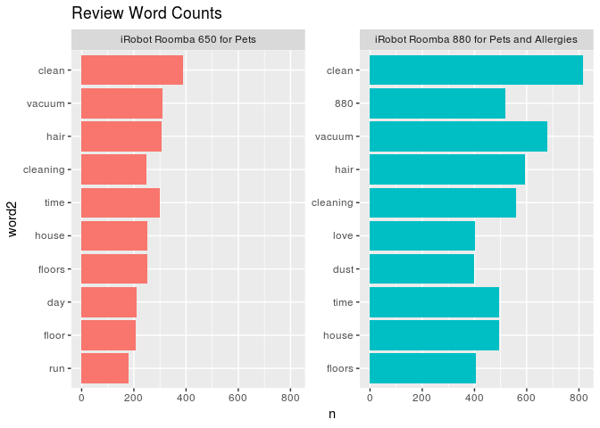

```r
ggplot(word_counts, aes(word2, n, fill = Product)) +
  geom_col(show.legend = FALSE) +
  facet_wrap(~ Product, scales = "free_y") +
  coord_flip() +
  ggtitle("Review Word Counts")
```

## Counting by product and reordering

### Instructions

- Count words by whether or not its a complaint.
- Keep the top 20 words by whether or not its a complaint.
- Ungroup before reordering word as a factor by the count.

### script.R

```r
word_counts <- tidy_twitter %>%
  # Count words by whether or not its a complaint
  count(word, complaint_label) %>%
  # Group by whether or not its a complaint
  group_by(complaint_label) %>%
  # Keep the top 20 words
  top_n(20, n) %>%
  # Ungroup before reordering word as a factor by the count
  ungroup() %>%
  mutate(word2 = fct_reorder(word, n))
```

## Visualizing word counts with facets

### Exercise

The `word_counts` from the previous exercise have been loaded. Let’s visualize the word counts for the Twitter data with separate facets for complaints and non-complaints.

### Instructions

- Include a color aesthetic tied to whether or not its a complaint.
- Don’t include the lengend for the column plot.
- Facet by whether or not the tweet comes from a complaint and make the y-axis free.
- Flip the coordinates and add a title: “Twitter Word Counts”.

### script.R

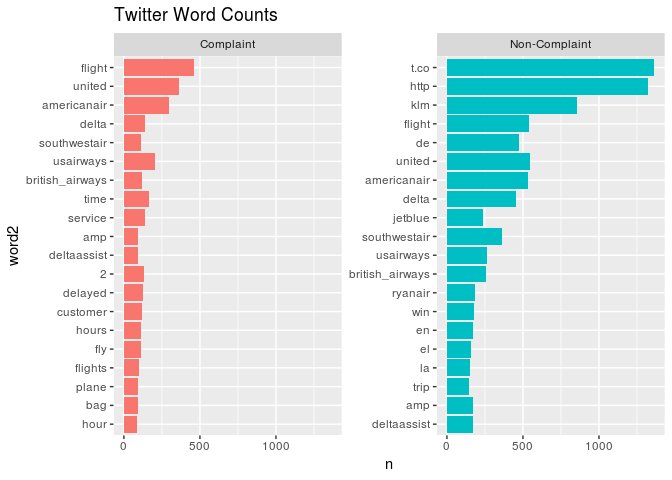

```r
# Include a color aesthetic tied to whether or not its a complaint
ggplot(word_counts, aes(word2, n, fill = complaint_label)) +
  # Don't include the lengend for the column plot
  geom_col(show.legend = FALSE) +
  # Facet by whether or not its a complaint and make the y-axis free
  facet_wrap(~ complaint_label, scales = "free_y") +
  # Flip the coordinatesa and a title: "Twitter Word Counts"
  coord_flip() +
  ggtitle("Twitter Word Counts")
```

## Plotting word clouds

**Using wordcloud()**

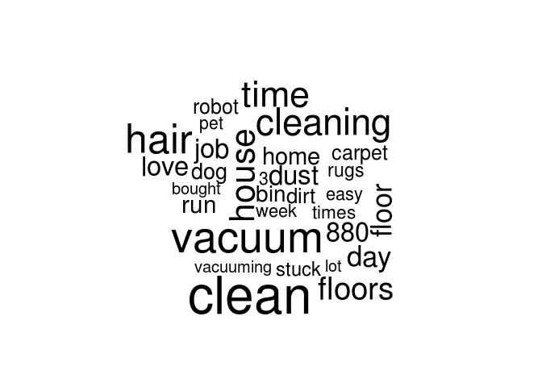

```r
library(wordcloud)
## Loading required package: RColorBrewer

word_counts <- tidy_review %>%
  count(word)

wordcloud(
  words = word_counts$word,
  freq = word_counts$n,
  max.words = 30
)
```

**Fixed size and random start points**

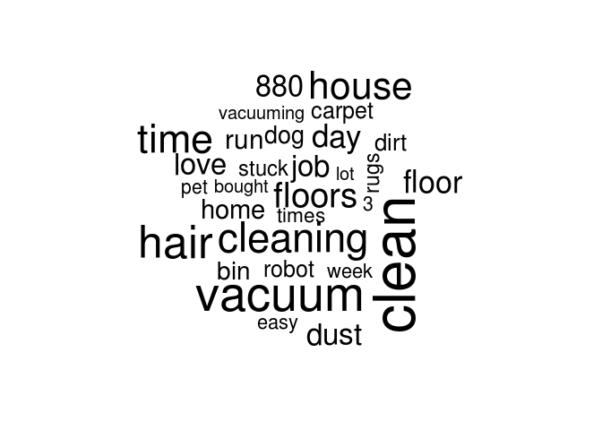

```r
wordcloud(
  words = word_counts$word,
  freq = word_counts$n,
  max.words = 30
)
```

**Number of words in the cloud**

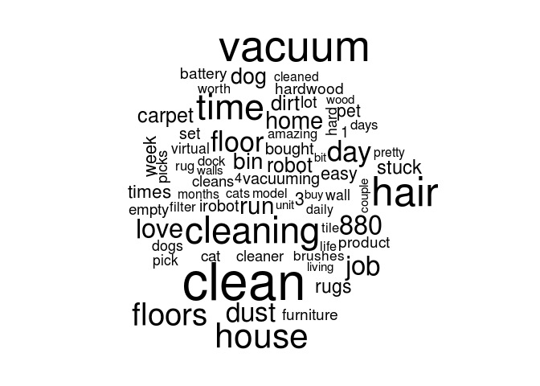

```r
wordcloud(
  words = word_counts$word,
  freq = word_counts$n,
  max.words = 70
)
```

**Using colors**

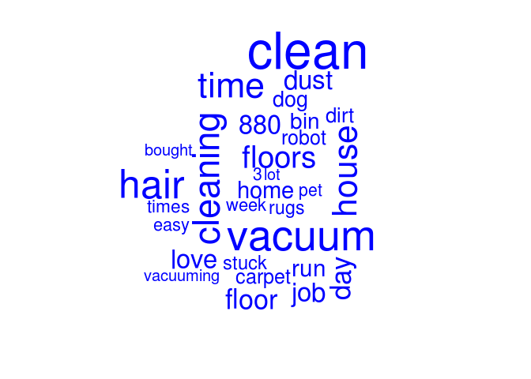

```r
wordcloud(
  words = word_counts$word,
  freq = word_counts$n,
  max.words = 30,
  colors = "blue"
)
```

## Creating a word cloud

### Exercise

We’ve seen bar plots, now let’s visualize word counts with word clouds! `tidy_twitter` has already been loaded, tokenized, and cleaned.

### Instructions

- Load the `wordcloud` package.
- Compute the word counts and assign to `word_counts`.
- Assign the word column from `word_counts` to the `words` argument.
- Assign the count column (`n`) from `word_counts` to the `freq` argument.

### script.R

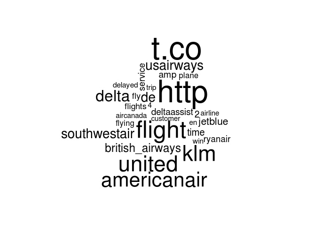

```r
# Load the wordcloud package
library(wordcloud)

# Compute word counts and assign to word_counts
word_counts <- tidy_twitter %>%
  count(word)

wordcloud(
  # Assign the word column to words
  words = word_counts$word,
  freq = word_counts$n,
  max.words = 30
)
```

## Adding a splash of color

### Exercise

What about just the complaints? And let’s add some color. Red seems appropriate. The `wordcloud` package has been loaded along with `tidy_twitter`.

### Instructions

- Compute the word counts only for the complaints and assign it to word_counts.
- Create a complaint word cloud of the top 50 terms, colored red.

### script.R

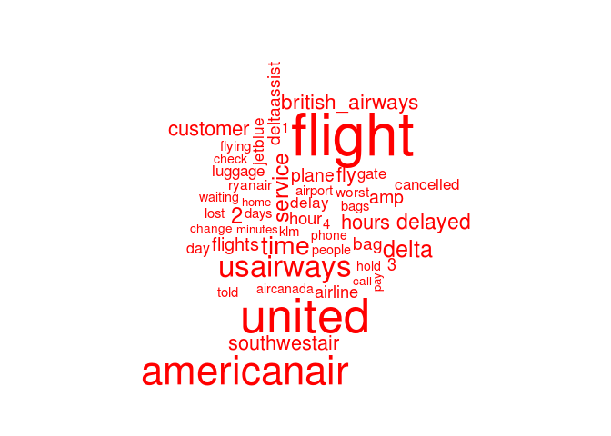

```r
# Compute complaint word counts and assign to word_counts
word_counts <- tidy_twitter %>%
  filter(complaint_label == "Complaint") %>%
  count(word)

# Create a complaint word cloud of the top 50 terms, colored red
wordcloud(
  words = word_counts$word,
  freq = word_counts$n,
  max.words = 50,
  colors = "red"
)
```